# R Learning - Ch4. 資料視覺化

### **圓餅圖**

要用`ggplot2`畫圓餅圖，要先畫出bar plot，再沿著y軸進行轉軸：

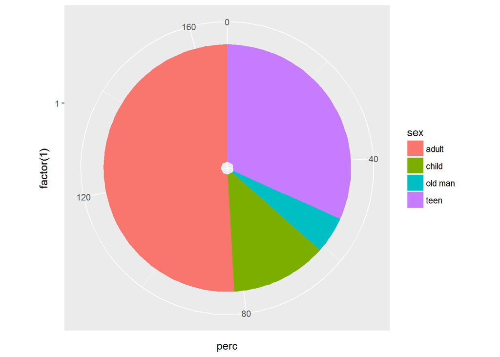

```r
# 自己定義一筆新的資料
df <- data.frame(sex=c("child", "teen", "adult", "old man"),
                 perc=c(21,53,85,8)
                 )

#準備畫布
ggplot(data=df) +

    # 先畫bar plot
    geom_bar(aes(x=factor(1),
                 y=perc,
                 fill=sex),
             stat = "identity"
             ) +

    # 再沿著Y，轉軸成圓餅圖
    coord_polar("y", start=0)
```

# **4. 儲存圖片成png,jpeg,bmp…**

如今，你已經學會如何運用R的繪圖系統，來將資料以圖形的方式呈現出來了~

但當你用R畫完圖以後，它只存在於R的暫存記憶體裡面，需要透過**手動**的方式存取。 因此，若我們想將圖片**自動**儲存到自己的電腦上，這才是我們最終的目的。

要用R把圖片輸出其實很簡單，例如我們要把畫好的圖片輸出成.png的型態，那我們就在前後加上`png()`和`dev.off()`，把我們繪圖的程式碼包起來，就像這樣：

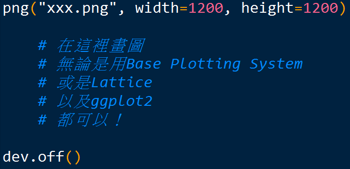

**注意!!! png() 裡面放的是檔案的路徑與檔名，*需要加上副檔名*，並同時設定輸出檔案的長寬**  
(jpeg對應的`jpeg()`，bmp對應的是`bmp()`，pdf對應的是`pdf()`)

我們拿上面ggplot2畫的「複合式圖表」為例，並對它進行輸出，程式碼如下：

```r
#表示要儲存成png的格式
png("Combination of Plots.png", width=600, height=600)

    ##複合式圖表 ##
    ggplot(data=airquality) +

        # 散布圖對應的函式是geom_point()
        geom_point(aes(x=Temp,
                       y=Ozone,
                       main="Scatter Plot of Ozone-Temp",
                       color=Month)
        ) +
        # 要畫線的話，對應的函式是geom_line()
        geom_line(aes(x=Temp,
                      y=Ozone,
                      color=Month)
        ) +

        # 用labs()，進行文字上的標註(Annotation)
        labs(title="Combination of Scatter and Line Plots",
             x="Temp",
             y="Ozone"
        ) +

        theme_bw()

dev.off() #最後要關掉輸出圖片裝置
```

# **總結**

這篇筆記由簡到難，介紹了不同的繪圖套件。當然，我們也可以用不同的繪圖套件，去繪製相同效果的圖表(雖然外觀上可能會不太一樣)。雖然內容很多，學起來不太容易，但畢竟人是視覺的生物，好好掌握資料視覺化(繪圖)的技巧，在資料分析與呈現上，是一項很重要的能力。

# **(額外)資料視覺化的資源**

- 台灣資料科學愛好者年會的演講：[[資料視覺化之理論、賞析與實作—投影片]](http://www.slideshare.net/tw_dsconf/ss-60041639) (2016/03/26)
- [[資料視覺化]](http://blog.infographics.tw/) ，與其[[臉書專頁]](https://www.facebook.com/data.visualize/)
- [[用數據看台灣]](https://www.facebook.com/taiwanstat/?fref=ts)

> **Reference - skydome20** [【R系列筆記】](http://rpubs.com/skydome20/Table)